# Análise exploratória de dados

Gabriela Motta, Italo Medeiros, Rafaela Lacerda

22 de dezembro de 2017

# Análises descritiva de dados

Olhando rapidamente a estrutura dos dados

```
## Observations: 320
## Variables: 4
## $ orgao      <chr> "http://http://www.cultura.gov.br", "http://http://...
## $ link       <chr> "https://cidadao.reclameaqui.com.br/277684/minister...
## $ titulo     <chr> "Ministério da cultura libera verba para biografia ...
## $ reclamacao <chr> "\r\n        Indignada com a liberação da verba de ...
```

```
## Observations: 86
## Variables: 2
## $ orgao <chr> "Ministério da Fazenda", "Ministério da Integração Na......
## $ link  <chr> "https://cidadao.reclameaqui.com.br/indices/lista_reclam...
```

```
## Observations: 163
## Variables: 3
## $ mat_avaliador <int> 112110089, 112110089, 112110089, 114111372, 1141...
## $ id_reclamação <int> 9, 19, 29, 2, 12, 89, NA, 39, 49, 59, 69, 79, 89...
## $ insatisfação  <dbl> 1.0, 3.0, 4.0, 4.5, 2.5, 5.0, NA, 3.0, 1.0, 2.0,...
```

## Análise dos dados

Abaixo, geramos algumas visualizações que nos ajudarão a melhor compreender o comportamento de algumas variáveis de interesse das nossas bases de dados:

### Boxplot do tamanho da reclamação (num de chars)

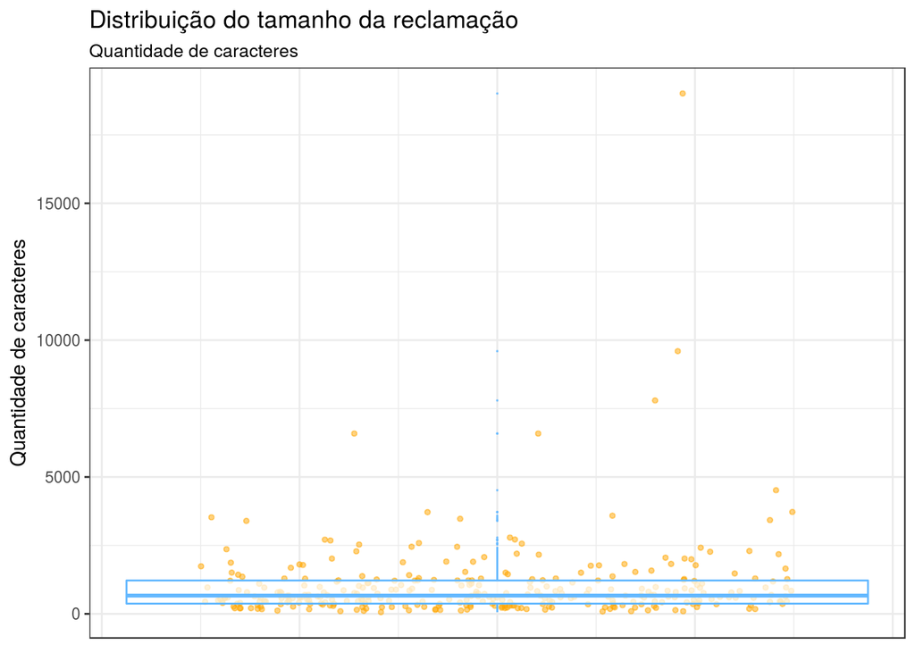

Nessa distribuição podemos observar que, geralmente, a quantidade de caracteres em uma reclamação está entre 0 e 5000 caracteres. Porém, existem casos em que esse número é bem mais alto, chegando a um máximo de quase 19000 caracteres.

### Boxplot do tamanho da reclamação (num de palavras)

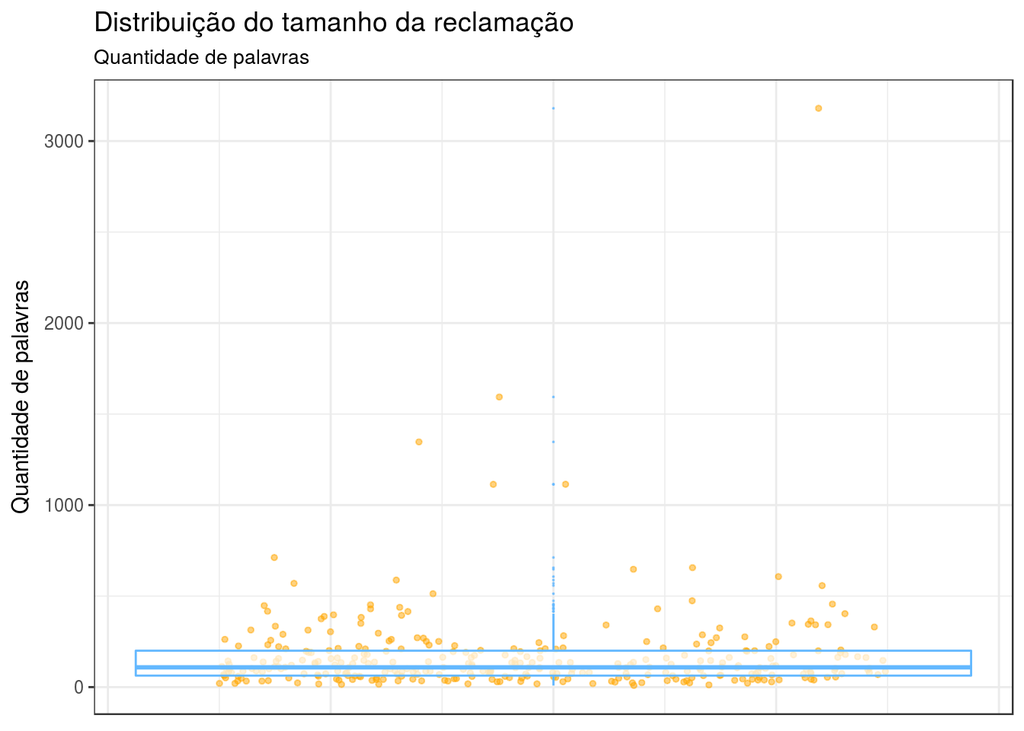

Nessa distribuição observamos que a grande maioria das reclamações possuem entre 0 e 500 palavras. Porém, existem algumas que são mais extensas, alcançando um máximo de aproximadamente 3200 palavras

### Boxplot da quantidade palavras em caixa alta

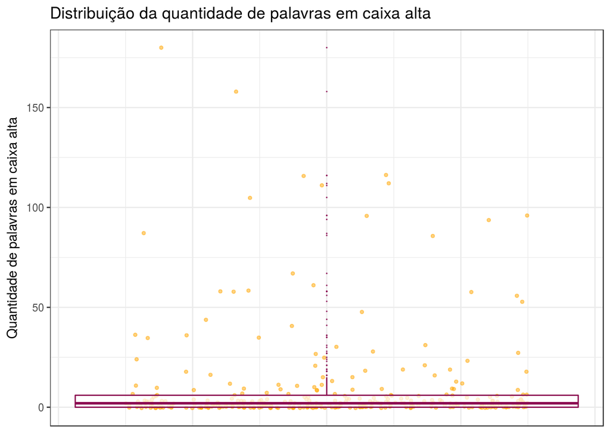

A partir dessa distribuição podemos observar que o número de palavras em caixa alta geralmente é baixo, entre 0 e 25. Porém, existem casos em que esse número se amplia drasticamente, chegando a mais de 150 palavras em caixa alta.

### Boxplot do tamanho da reclamação (num de palavras) por órgão

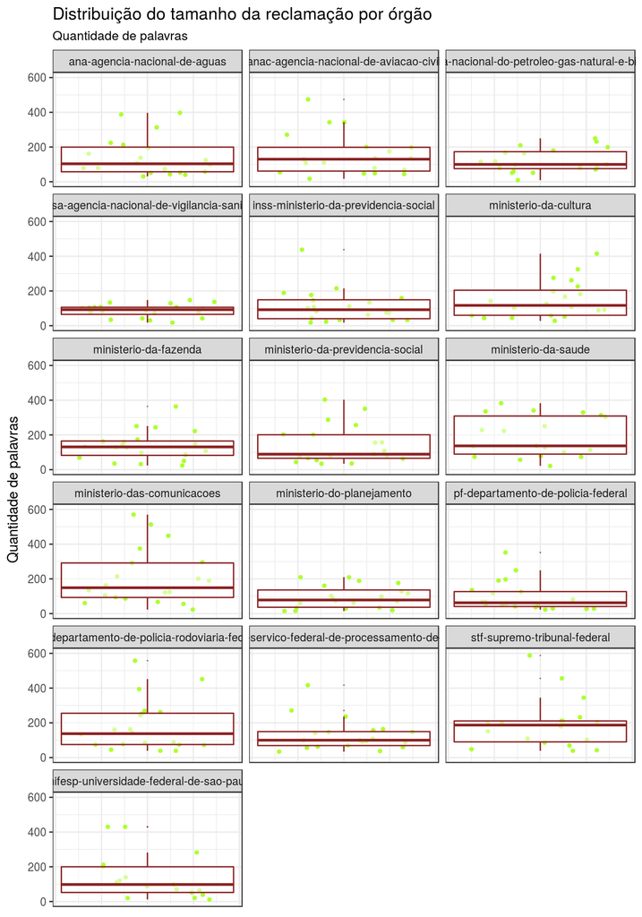

Nessa distribuição podemos ver que muitos órgãos recebem reclamações pequenas, como por exemplo a ANVISA que concentra todas as suas reclamações com menos de 200 palavras. O Ministério das Comunicações recebe as maiores reclamações, sendo 25% entre 300 e 600 palavras.

### Boxplot da quantidade de palavras em caixa alta por órgão

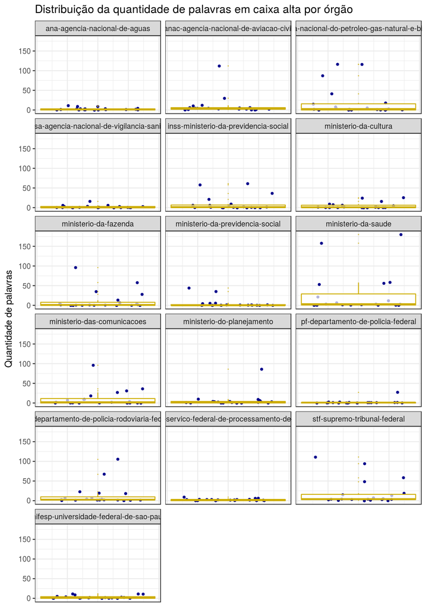

Aqui vemos que o número de palavras em caixa alta por reclamação é baixo, sendo os outliers as reclamações que possuíam todas as palavras em caixa alta. Enquanto a maioria dos órgãos concentra todas as reclamações em uma quantidade de palavras em caixa alta abaixo de 10, o Ministério da Saúde possui 50% das reclamações com cerca de 25 palavras em caixa alta.

### Mediana da insatisfação por reclamação

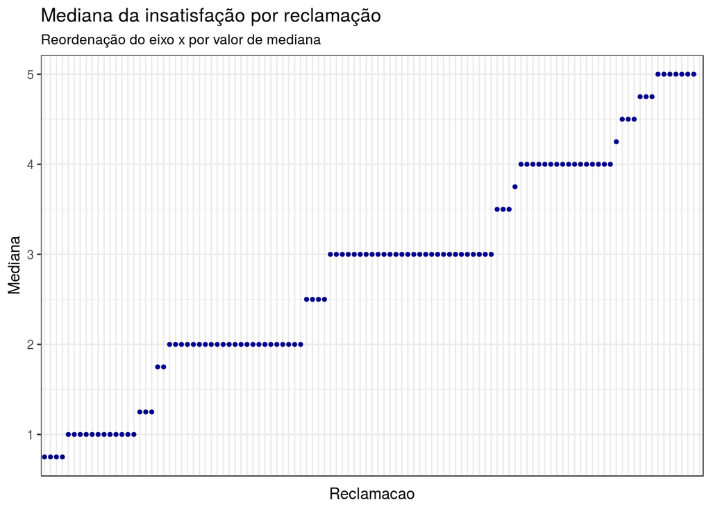

A partir do gráfico, podemos concluir que mais de 50% das reclamações teve uma mediana entre 3 e 5. Mostrando que, geralmente há um nível considerável de insatisfação entre as reclamações. Além disso, nota-se que nas reclamações cuja mediana foi 5, os avaliadores deram nota máxima em, pelo menos, 50% das reclamações. Analogamente, podemos afirmar que naquelas em que a mediana foi 1, pelo menos, 50% dos avaliadores deram nota mínima.

### Distribuição do valor da insatisfação por órgão

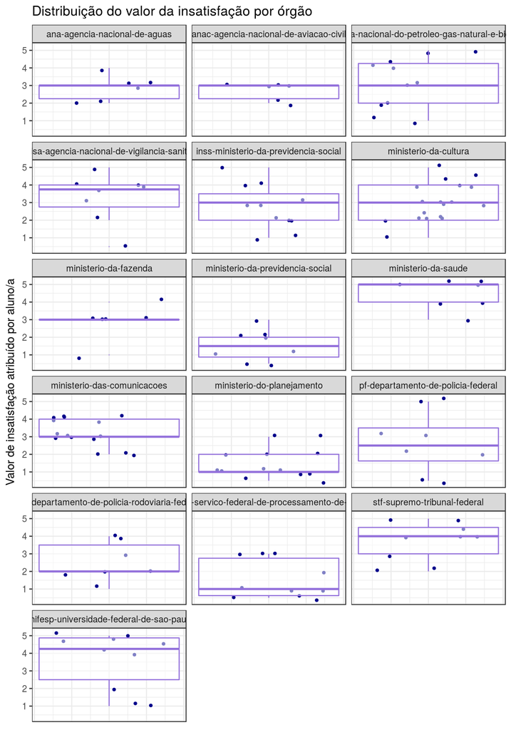

Nestes gráficos podemos perceber que alguns órgãos concentram reclamações em torno de um certo grau de insatisfação, como é o caso do Ministério da Saúde que possui 50% das reclamações de grau 5. O Ministério da Fazenda chama a atenção por concentrar quase todos os valores no grau 3. A Agência Nacional de Petróleo, Gás Natural e Biocombustível possui os dados mais uniformes, sendo 50% entre 1 e 3, e 50% entre 3 e 5.